# Funkcije više varijabli u pythonu

```python
import platform
```

```python
platform.platform()
```

```
'Linux-5.4.143-1-MANJARO-x86_64-with-glibc2.33'
```

```python
platform.python_version()
```

```
'3.9.6'
```

```python
import sympy as sp
```

```python
sp.init_printing()
```

```python
sp.__version__
```

```
'1.8'
```

```python
x,y,z,t,u,v=sp.symbols('x y z t u v',real=True)
```

```python
import matplotlib.pyplot as plt
```

```python
%pylab inline
from mpl_toolkits.mplot3d import Axes3D
```

## Parcijalne derivacije

$f(x,y)=(x^2+y)\cos{\big(x^3y^2\big)}$

```python
f=(x**2+y)*sp.cos(x**3*y**2)
f
```

$\displaystyle \left(x^{2} + y\right) \cos{\left(x^{3} y^{2} \right)}$

Računanje vrijednosti funkcije u točki

```python
f.evalf(subs={x:2,y:3})
```

$\displaystyle -6.77075411791718$

$\dfrac{\partial f}{\partial x}$

```python
f.diff(x)
```

$\displaystyle - 3 x^{2} y^{2} \left(x^{2} + y\right) \sin{\left(x^{3} y^{2} \right)} + 2 x \cos{\left(x^{3} y^{2} \right)}$

```python
sp.diff(f,x)
```

$\displaystyle - 3 x^{2} y^{2} \left(x^{2} + y\right) \sin{\left(x^{3} y^{2} \right)} + 2 x \cos{\left(x^{3} y^{2} \right)}$

Ako je moguće, možemo faktorizirati izraz.

```python
f.diff(x).factor()
```

$\displaystyle - x \left(3 x^{3} y^{2} \sin{\left(x^{3} y^{2} \right)} + 3 x y^{3} \sin{\left(x^{3} y^{2} \right)} - 2 \cos{\left(x^{3} y^{2} \right)}\right)$

$\dfrac{\partial f}{\partial y}$

```python
f.diff(y)
```

$\displaystyle - 2 x^{3} y \left(x^{2} + y\right) \sin{\left(x^{3} y^{2} \right)} + \cos{\left(x^{3} y^{2} \right)}$

```python
sp.diff(f,y)
```

$\displaystyle - 2 x^{3} y \left(x^{2} + y\right) \sin{\left(x^{3} y^{2} \right)} + \cos{\left(x^{3} y^{2} \right)}$

$\dfrac{\partial f}{\partial y}(2,3)$

```python
fy=f.diff(y)
fy.evalf(subs={x:2,y:3})
```

$\displaystyle -86.2519004763181$

$\dfrac{\partial^2 f}{\partial x^2}$

```python
f.diff(x,2)
```

$\displaystyle - 12 x^{3} y^{2} \sin{\left(x^{3} y^{2} \right)} - 3 x y^{2} \left(x^{2} + y\right) \left(3 x^{3} y^{2} \cos{\left(x^{3} y^{2} \right)} + 2 \sin{\left(x^{3} y^{2} \right)}\right) + 2 \cos{\left(x^{3} y^{2} \right)}$

Možemo probati malo pojednostavniti izraz

```python
f.diff(x,2).simplify()
```

$\displaystyle - 12 x^{3} y^{2} \sin{\left(x^{3} y^{2} \right)} - 3 x y^{2} \left(x^{2} + y\right) \left(3 x^{3} y^{2} \cos{\left(x^{3} y^{2} \right)} + 2 \sin{\left(x^{3} y^{2} \right)}\right) + 2 \cos{\left(x^{3} y^{2} \right)}$

```python
f.diff(x,2).expand()
```

$\displaystyle - 9 x^{6} y^{4} \cos{\left(x^{3} y^{2} \right)} - 9 x^{4} y^{5} \cos{\left(x^{3} y^{2} \right)} - 18 x^{3} y^{2} \sin{\left(x^{3} y^{2} \right)} - 6 x y^{3} \sin{\left(x^{3} y^{2} \right)} + 2 \cos{\left(x^{3} y^{2} \right)}$

$\dfrac{\partial^2 f}{\partial y^2}$

```python
f.diff(y,2)
```

$\displaystyle - 2 x^{3} \left(2 y \sin{\left(x^{3} y^{2} \right)} + \left(x^{2} + y\right) \left(2 x^{3} y^{2} \cos{\left(x^{3} y^{2} \right)} + \sin{\left(x^{3} y^{2} \right)}\right)\right)$

Možemo se opet igrati s pojednostavljivanjem izraza

```python
f.diff(y,2).expand()
```

$\displaystyle - 4 x^{8} y^{2} \cos{\left(x^{3} y^{2} \right)} - 4 x^{6} y^{3} \cos{\left(x^{3} y^{2} \right)} - 2 x^{5} \sin{\left(x^{3} y^{2} \right)} - 6 x^{3} y \sin{\left(x^{3} y^{2} \right)}$

```python
f.diff(y,2).expand().factor()
```

$\displaystyle - 2 x^{3} \left(2 x^{5} y^{2} \cos{\left(x^{3} y^{2} \right)} + 2 x^{3} y^{3} \cos{\left(x^{3} y^{2} \right)} + x^{2} \sin{\left(x^{3} y^{2} \right)} + 3 y \sin{\left(x^{3} y^{2} \right)}\right)$

$\dfrac{\partial^2 f}{\partial x\partial y}$

```python
fxy=f.diff(x,1,y,1)
fxy
```

$\displaystyle - x^{2} y \left(6 x^{3} y^{2} \left(x^{2} + y\right) \cos{\left(x^{3} y^{2} \right)} + 4 x^{2} \sin{\left(x^{3} y^{2} \right)} + 3 y \sin{\left(x^{3} y^{2} \right)} + 6 \left(x^{2} + y\right) \sin{\left(x^{3} y^{2} \right)}\right)$

```python
fxy.expand()
```

$\displaystyle - 6 x^{7} y^{3} \cos{\left(x^{3} y^{2} \right)} - 6 x^{5} y^{4} \cos{\left(x^{3} y^{2} \right)} - 10 x^{4} y \sin{\left(x^{3} y^{2} \right)} - 9 x^{2} y^{2} \sin{\left(x^{3} y^{2} \right)}$

```python
fxy.expand().factor()
```

$\displaystyle - x^{2} y \left(6 x^{5} y^{2} \cos{\left(x^{3} y^{2} \right)} + 6 x^{3} y^{3} \cos{\left(x^{3} y^{2} \right)} + 10 x^{2} \sin{\left(x^{3} y^{2} \right)} + 9 y \sin{\left(x^{3} y^{2} \right)}\right)$

#### Hesseova matrica

```python
hess_f=sp.hessian(f,[x,y])
hess_f
```

$\displaystyle \left[\begin{matrix}- 9 x^{4} y^{4} \left(x^{2} + y\right) \cos{\left(x^{3} y^{2} \right)} - 12 x^{3} y^{2} \sin{\left(x^{3} y^{2} \right)} - 6 x y^{2} \left(x^{2} + y\right) \sin{\left(x^{3} y^{2} \right)} + 2 \cos{\left(x^{3} y^{2} \right)} & - 6 x^{5} y^{3} \left(x^{2} + y\right) \cos{\left(x^{3} y^{2} \right)} - 4 x^{4} y \sin{\left(x^{3} y^{2} \right)} - 3 x^{2} y^{2} \sin{\left(x^{3} y^{2} \right)} - 6 x^{2} y \left(x^{2} + y\right) \sin{\left(x^{3} y^{2} \right)}\\- 6 x^{5} y^{3} \left(x^{2} + y\right) \cos{\left(x^{3} y^{2} \right)} - 4 x^{4} y \sin{\left(x^{3} y^{2} \right)} - 3 x^{2} y^{2} \sin{\left(x^{3} y^{2} \right)} - 6 x^{2} y \left(x^{2} + y\right) \sin{\left(x^{3} y^{2} \right)} & - 4 x^{6} y^{2} \left(x^{2} + y\right) \cos{\left(x^{3} y^{2} \right)} - 4 x^{3} y \sin{\left(x^{3} y^{2} \right)} - 2 x^{3} \left(x^{2} + y\right) \sin{\left(x^{3} y^{2} \right)}\end{matrix}\right]$

Hesseova matrica funkcije $f$ u točki $(2,3)$

```python
mat23=hess_f.evalf(subs={x:2,y:3})
mat23
```

$\displaystyle \left[\begin{matrix}78560.9476825349 & 34895.515363622\\34895.515363622 & 15547.0222282267\end{matrix}\right]$

#### Hesseova determinanta

```python
hess_f.det()
```

$\displaystyle - 30 x^{11} y^{4} \sin{\left(x^{3} y^{2} \right)} \cos{\left(x^{3} y^{2} \right)} - 60 x^{9} y^{5} \sin{\left(x^{3} y^{2} \right)} \cos{\left(x^{3} y^{2} \right)} - 64 x^{8} y^{2} \sin^{2}{\left(x^{3} y^{2} \right)} - 8 x^{8} y^{2} \cos^{2}{\left(x^{3} y^{2} \right)} - 30 x^{7} y^{6} \sin{\left(x^{3} y^{2} \right)} \cos{\left(x^{3} y^{2} \right)} - 60 x^{6} y^{3} \sin^{2}{\left(x^{3} y^{2} \right)} - 8 x^{6} y^{3} \cos^{2}{\left(x^{3} y^{2} \right)} - 4 x^{5} \sin{\left(x^{3} y^{2} \right)} \cos{\left(x^{3} y^{2} \right)} - 45 x^{4} y^{4} \sin^{2}{\left(x^{3} y^{2} \right)} - 12 x^{3} y \sin{\left(x^{3} y^{2} \right)} \cos{\left(x^{3} y^{2} \right)}$

```python
hess_f.det().simplify()
```

$\displaystyle x^{3} \left(- 15 x^{8} y^{4} \sin{\left(2 x^{3} y^{2} \right)} - 30 x^{6} y^{5} \sin{\left(2 x^{3} y^{2} \right)} + 28 x^{5} y^{2} \cos{\left(2 x^{3} y^{2} \right)} - 36 x^{5} y^{2} - 15 x^{4} y^{6} \sin{\left(2 x^{3} y^{2} \right)} + 26 x^{3} y^{3} \cos{\left(2 x^{3} y^{2} \right)} - 34 x^{3} y^{3} - 2 x^{2} \sin{\left(2 x^{3} y^{2} \right)} + \frac{45 x y^{4} \cos{\left(2 x^{3} y^{2} \right)}}{2} - \frac{45 x y^{4}}{2} - 6 y \sin{\left(2 x^{3} y^{2} \right)}\right)$

Hesseova determinanta u točki $(2,3)$

```python
mat23.det()
```

$\displaystyle 3691807.39814615$

$\dfrac{\partial^3 f}{\partial x^2\partial y}$

```python
f_x2y=f.diff(x,2,y,1)
f_x2y
```

$\displaystyle x y \left(- 24 x^{5} y^{2} \cos{\left(x^{3} y^{2} \right)} + 6 x^{3} y^{2} \left(x^{2} + y\right) \left(3 x^{3} y^{2} \sin{\left(x^{3} y^{2} \right)} - 5 \cos{\left(x^{3} y^{2} \right)}\right) - 28 x^{2} \sin{\left(x^{3} y^{2} \right)} - 3 y \left(3 x^{3} y^{2} \cos{\left(x^{3} y^{2} \right)} + 2 \sin{\left(x^{3} y^{2} \right)}\right) - 6 \left(x^{2} + y\right) \left(3 x^{3} y^{2} \cos{\left(x^{3} y^{2} \right)} + 2 \sin{\left(x^{3} y^{2} \right)}\right)\right)$

```python
f_x2y=f_x2y.simplify()
f_x2y
```

$\displaystyle x y \left(18 x^{8} y^{4} \sin{\left(x^{3} y^{2} \right)} + 18 x^{6} y^{5} \sin{\left(x^{3} y^{2} \right)} - 72 x^{5} y^{2} \cos{\left(x^{3} y^{2} \right)} - 57 x^{3} y^{3} \cos{\left(x^{3} y^{2} \right)} - 40 x^{2} \sin{\left(x^{3} y^{2} \right)} - 18 y \sin{\left(x^{3} y^{2} \right)}\right)$

$\dfrac{\partial^3 f}{\partial x^2\partial y}(2,3)$

```python
f_x2y.evalf(subs={x:2,y:3})
```

$\displaystyle 1186228.43174401$

na više znamenaka

```python
f_x2y.evalf(n=30,subs={x:2,y:3})
```

$\displaystyle 1186228.43174401256199541146793$

### Funkcija tri varijable

$g(x,y,z)=x\log_2{\big(3x+z^4\big)}+5xyz$

```python
g=x*sp.log(3*x+z**4,2)+5*x*y*z
g
```

$\displaystyle 5 x y z + \frac{x \log{\left(3 x + z^{4} \right)}}{\log{\left(2 \right)}}$

#### parcijalne derivacije

```python
g.diff(x)
```

$\displaystyle \frac{3 x}{\left(3 x + z^{4}\right) \log{\left(2 \right)}} + 5 y z + \frac{\log{\left(3 x + z^{4} \right)}}{\log{\left(2 \right)}}$

```python
g.diff(y)
```

$\displaystyle 5 x z$

```python
g.diff(z)
```

$\displaystyle 5 x y + \frac{4 x z^{3}}{\left(3 x + z^{4}\right) \log{\left(2 \right)}}$

$\dfrac{\partial g}{\partial x}(1,-2,2.14)$

```python
g.diff(x).evalf(subs={x:1,y:-2,z:2.14})
```

$\displaystyle -16.6361353482274$

$\dfrac{\partial^2 g}{\partial x\partial z}$

```python
g.diff(x,1,z,1)
```

$\displaystyle - \frac{12 x z^{3}}{\left(3 x + z^{4}\right)^{2} \log{\left(2 \right)}} + 5 y + \frac{4 z^{3}}{\left(3 x + z^{4}\right) \log{\left(2 \right)}}$

#### Hesseova matrica

```python
hess_g=sp.hessian(g,[x,y,z])
hess_g
```

$\displaystyle \left[\begin{matrix}- \frac{9 x}{\left(3 x + z^{4}\right)^{2} \log{\left(2 \right)}} + \frac{6}{\left(3 x + z^{4}\right) \log{\left(2 \right)}} & 5 z & - \frac{12 x z^{3}}{\left(3 x + z^{4}\right)^{2} \log{\left(2 \right)}} + 5 y + \frac{4 z^{3}}{\left(3 x + z^{4}\right) \log{\left(2 \right)}}\\5 z & 0 & 5 x\\- \frac{12 x z^{3}}{\left(3 x + z^{4}\right)^{2} \log{\left(2 \right)}} + 5 y + \frac{4 z^{3}}{\left(3 x + z^{4}\right) \log{\left(2 \right)}} & 5 x & - \frac{16 x z^{6}}{\left(3 x + z^{4}\right)^{2} \log{\left(2 \right)}} + \frac{12 x z^{2}}{\left(3 x + z^{4}\right) \log{\left(2 \right)}}\end{matrix}\right]$

Hesseova matrica funkcije $g$ u točki $(1,-2,2.14)$

```python
hess_g.evalf(subs={x:1,y:-2,z:2.14})
```

$\displaystyle \left[\begin{matrix}0.338490536391147 & 10.7 & -7.93606634673305\\10.7 & 0 & 5.0\\-7.93606634673305 & 5.0 & -0.550579805307276\end{matrix}\right]$

#### Hesseova determinanta

```python
hess_g.det()
```

$\displaystyle \frac{2250 x^{3} y z \log{\left(2 \right)} - 225 x^{3} + 1500 x^{2} y z^{5} \log{\left(2 \right)} - 1050 x^{2} z^{4} + 250 x y z^{9} \log{\left(2 \right)} + 300 x z^{8}}{9 x^{2} \log{\left(2 \right)} + 6 x z^{4} \log{\left(2 \right)} + z^{8} \log{\left(2 \right)}}$

```python
g_det=hess_g.det().simplify()
g_det
```

$\displaystyle \frac{25 x \left(- 9 x^{2} - 42 x z^{4} + 12 z^{8} + \log{\left(2^{10 y z \left(9 x^{2} + 6 x z^{4} + z^{8}\right)} \right)}\right)}{\left(9 x^{2} + 6 x z^{4} + z^{8}\right) \log{\left(2 \right)}}$

**Hesseova determinanta funkcije $g$ u točki $(1,-2,2.14)$**

Možemo prvo odrediti općeniti izraz za Hesseovu determinantu pa uvrstiti konkretnu točku, ili možemo prvo uvrstiti točku da dobijemo Hesseovu matricu u konkretnoj točki pa računati determinantu s konkretnim brojevima.

```python
g_det.evalf(subs={x:1,y:-2,z:2.14})
```

$\displaystyle -794.585480600585$

```python
hess_g.evalf(subs={x:1,y:-2,z:2.14}).det()
```

$\displaystyle -794.585480600585$

$\dfrac{\partial^5 g}{\partial x^2\partial z^3}$

```python
g_x2z3=g.diff(x,2,z,3)
g_x2z3
```

$\displaystyle \frac{144 z \left(\frac{96 x z^{8}}{\left(3 x + z^{4}\right)^{3}} - \frac{54 x z^{4}}{\left(3 x + z^{4}\right)^{2}} + \frac{3 x}{3 x + z^{4}} - \frac{16 z^{8}}{\left(3 x + z^{4}\right)^{2}} + \frac{12 z^{4}}{3 x + z^{4}} - 1\right)}{\left(3 x + z^{4}\right)^{2} \log{\left(2 \right)}}$

```python
g_x2z3=g_x2z3.simplify()
g_x2z3
```

$\displaystyle \frac{z^{5} \left(- 9072 x^{2} + 8640 x z^{4} - 720 z^{8}\right)}{\left(243 x^{5} + 405 x^{4} z^{4} + 270 x^{3} z^{8} + 90 x^{2} z^{12} + 15 x z^{16} + z^{20}\right) \log{\left(2 \right)}}$

$\dfrac{\partial^5 g}{\partial x^2\partial z^3}(1,-2,2.14)$

```python
g_x2z3.evalf(subs={x:1,y:-2,z:2.14})
```

$\displaystyle -1.18226393361736$

$\dfrac{\partial^3 g}{\partial x\partial y\partial z}$

```python
g.diff(x,1,y,1,z,1)
```

$\displaystyle 5$

$\dfrac{\partial^4 g}{\partial x^2\partial y\partial z}$

```python
g.diff(x,2,y,1,z,1)
```

$\displaystyle 0$

### Vektorske funkcije

$r_1(u)=\big(u^2,sin(u),u^3+\frac{1}{u}\big)$

```python
r1=sp.Matrix([u**2,sp.sin(u),u**3+1/u])
r1
```

$\displaystyle \left[\begin{matrix}u^{2}\\\sin{\left(u \right)}\\u^{3} + \frac{1}{u}\end{matrix}\right]$

Derivacija vektorske funkcije jedne varijable

```python
r1.diff(u)
```

$\displaystyle \left[\begin{matrix}2 u\\\cos{\left(u \right)}\\3 u^{2} - \frac{1}{u^{2}}\end{matrix}\right]$

Druga derivacija vektorske funkcije jedne varijable

```python
r1.diff(u,2)
```

$\displaystyle \left[\begin{matrix}2\\- \sin{\left(u \right)}\\2 \left(3 u + \frac{1}{u^{3}}\right)\end{matrix}\right]$

```python
r1.diff(u,2).expand()
```

$\displaystyle \left[\begin{matrix}2\\- \sin{\left(u \right)}\\6 u + \frac{2}{u^{3}}\end{matrix}\right]$

Treća derivacija vektorske funkcije jedne varijable

```python
r1.diff(u,3)
```

$\displaystyle \left[\begin{matrix}0\\- \cos{\left(u \right)}\\6 \left(1 - \frac{1}{u^{4}}\right)\end{matrix}\right]$

```python
r1.diff(u,3).expand()
```

$\displaystyle \left[\begin{matrix}0\\- \cos{\left(u \right)}\\6 - \frac{6}{u^{4}}\end{matrix}\right]$

$\dfrac{\mathrm{d}r_1}{\mathrm{d}u}(1)$

```python
r1.diff(u).evalf(subs={u:1})
```

$\displaystyle \left[\begin{matrix}2.0\\0.54030230586814\\2.0\end{matrix}\right]$

$\dfrac{\mathrm{d}r_1}{\mathrm{d}u}\times\dfrac{\mathrm{d}^2r_1}{\mathrm{d}u^2}$

```python
r1_u=r1.diff(u)
r1_uu=r1.diff(u,2)
```

```python
vek=r1_u.cross(r1_uu)
vek
```

$\displaystyle \left[\begin{matrix}2 \left(3 u + \frac{1}{u^{3}}\right) \cos{\left(u \right)} + \left(3 u^{2} - \frac{1}{u^{2}}\right) \sin{\left(u \right)}\\6 u^{2} - 4 u \left(3 u + \frac{1}{u^{3}}\right) - \frac{2}{u^{2}}\\- 2 u \sin{\left(u \right)} - 2 \cos{\left(u \right)}\end{matrix}\right]$

$\dfrac{\mathrm{d}r_1}{\mathrm{d}u}(1)\times\dfrac{\mathrm{d}^2r_1}{\mathrm{d}u^2}(1)$

```python
vek.evalf(subs={u:1})
```

$\displaystyle \left[\begin{matrix}6.00536041656091\\-12.0\\-2.76354658135207\end{matrix}\right]$

Ili možemo prvi svaki vektor izračunati u točki $u=1$ pa vektorski produkt računati s konkretnim brojevima

```python
vek1=r1.diff(u).evalf(subs={u:1})
vek2=r1.diff(u,2).evalf(subs={u:1})
```

```python
vek1,vek2
```

$\displaystyle \left( \left[\begin{matrix}2.0\\0.54030230586814\\2.0\end{matrix}\right], \ \left[\begin{matrix}2.0\\-0.841470984807897\\8.0\end{matrix}\right]\right)$

```python
vek1.cross(vek2)
```

$\displaystyle \left[\begin{matrix}6.00536041656091\\-12.0\\-2.76354658135207\end{matrix}\right]$

#### Vektorska funkcija dvije varijable

$r_2(u,v)=\big(u\cos{v},u^2+3v\sin{v},v\sqrt{u}\big)$

```python
r2=sp.Matrix([u*sp.cos(v),u**2+3*v*sp.sin(v),v*u**sp.Rational(1,2)])
r2
```

$\displaystyle \left[\begin{matrix}u \cos{\left(v \right)}\\u^{2} + 3 v \sin{\left(v \right)}\\\sqrt{u} v\end{matrix}\right]$

Parcijalne derivacije

```python
r2.diff(u)
```

$\displaystyle \left[\begin{matrix}\cos{\left(v \right)}\\2 u\\\frac{v}{2 \sqrt{u}}\end{matrix}\right]$

```python
r2.diff(v)
```

$\displaystyle \left[\begin{matrix}- u \sin{\left(v \right)}\\3 v \cos{\left(v \right)} + 3 \sin{\left(v \right)}\\\sqrt{u}\end{matrix}\right]$

Vrijednosti parcijalnih derivacija u točki $(1,-2)$

```python
vek3=r2.diff(u).evalf(subs={u:1,v:-2})
vek3
```

$\displaystyle \left[\begin{matrix}-0.416146836547142\\2.0\\-1.0\end{matrix}\right]$

```python
vek4=r2.diff(v).evalf(subs={u:1,v:-2})
vek4
```

$\displaystyle \left[\begin{matrix}0.909297426825682\\-0.231011261194191\\1.0\end{matrix}\right]$

$\dfrac{\partial r_2}{\partial u}\times\dfrac{\partial r_2}{\partial v}$

```python
r2u_x_r2v=r2.diff(u).cross(r2.diff(v))
r2u_x_r2v
```

$\displaystyle \left[\begin{matrix}2 u^{\frac{3}{2}} - \frac{v \left(3 v \cos{\left(v \right)} + 3 \sin{\left(v \right)}\right)}{2 \sqrt{u}}\\- \frac{\sqrt{u} v \sin{\left(v \right)}}{2} - \sqrt{u} \cos{\left(v \right)}\\2 u^{2} \sin{\left(v \right)} + \left(3 v \cos{\left(v \right)} + 3 \sin{\left(v \right)}\right) \cos{\left(v \right)}\end{matrix}\right]$

$\dfrac{\partial r_2}{\partial u}(1,-2)\times\dfrac{\partial r_2}{\partial v}(1,-2)$

```python
r2u_x_r2v.evalf(subs={u:1,v:-2})
```

$\displaystyle \left[\begin{matrix}1.76898873880581\\-0.493150590278539\\-1.72246024809864\end{matrix}\right]$

Ili možemo prvi svaki vektor izračunati u točki $(1,-2)$ pa vektorski produkt računati s konkretnim brojevima

```python
vek3.cross(vek4)
```

$\displaystyle \left[\begin{matrix}1.76898873880581\\-0.493150590278539\\-1.72246024809864\end{matrix}\right]$

$\dfrac{\partial^3 r_2}{\partial u^2\partial v}$

```python
r2.diff(u,2,v,1)
```

$\displaystyle \left[\begin{matrix}0\\0\\- \frac{1}{4 u^{\frac{3}{2}}}\end{matrix}\right]$

## Zadaci

U nastavku dajemo rješenja nekoliko zadataka pomoću *sympy* modula. Također je dano nekoliko korisnih napomena kako bi se izbjeglo pogrešno korištenje *sympy* modula.

### 1. zadatak

Pomoću diferencijala aproksimirajte prirast funkcije $F(x,y)=x^2y+y\sin{\big(x^2+y^2\big)}$ u točki $(1,-7)$ ako je $\Delta x=0.03,$ $\Delta y=-0.12$. Usporedite tu aproksimaciju sa stvarnim prirastom.

### Rješenje

```python
F=x**2*y+y*sp.sin(x**2+y**2)
F
```

$\displaystyle x^{2} y + y \sin{\left(x^{2} + y^{2} \right)}$

Parcijalne derivacije funkcije $F$

```python
Fx=F.diff(x)
Fy=F.diff(y)
```

```python
Fx,Fy
```

$\displaystyle \left( 2 x y \cos{\left(x^{2} + y^{2} \right)} + 2 x y, \ x^{2} + 2 y^{2} \cos{\left(x^{2} + y^{2} \right)} + \sin{\left(x^{2} + y^{2} \right)}\right)$

Aproksimacija prirasta funkcije pomoću diferencijala

```python
Fx0=Fx.evalf(subs={x:1,y:-7})
Fy0=Fy.evalf(subs={x:1,y:-7})
```

```python
prirast_apr=Fx0*0.03+Fy0*(-0.12)
prirast_apr
```

$\displaystyle -12.2618012445895$

Stvarna vrijednost prirasta

```python
prirast=F.evalf(subs={x:1+0.03,y:-7-0.12}) - F.evalf(subs={x:1,y:-7})
prirast
```

$\displaystyle -9.48689980424778$

#### Graf funkcije $F$

```python
plt.rcParams['figure.figsize'] = 12,9
```

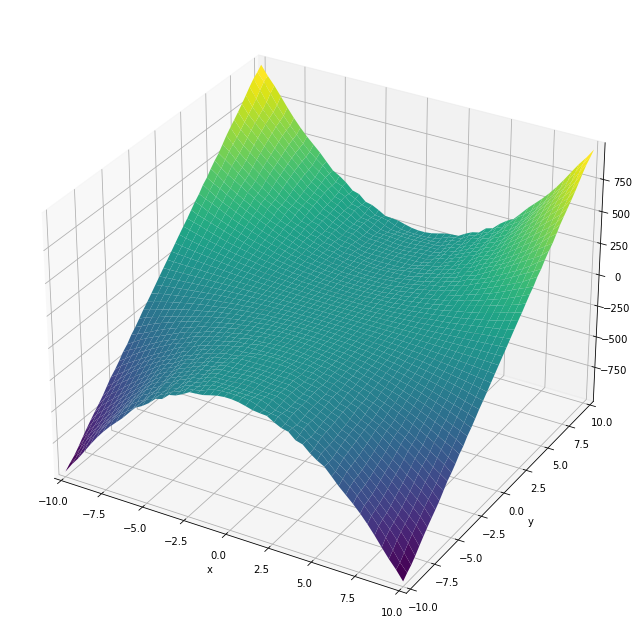

```python
sp.plotting.plot3d(F,(x,-10,10),(y,-10,10),xlabel='x',ylabel='y');
```

*Sympy* nudi brzo rješenje za crtanje ploha koje je bazirano na *matplotlibu* modulu. Prednost je da ne moramo pisati puno koda za dobivanje slike, a nedostatak je da nemamo puno slobode u kontroliranju izgleda slike. Ako želimo raditi više zahvata na samoj slici, onda je bolje da direktno koristimo *matplotlib* modul.

Namjerno je graf zumiran oko zadane točke $(1,-7)$ kako bismo vidjeli da moramo biti oprezni kod vizualizacije. Prethodna slika je nacrtana na puno većoj domeni i daje potpuno krivu predodžbu o izgledu same plohe jer dobivamo dojam da ploha nije uopće "brdovita". Donja slika daje vjerniji prikaz plohe. Stoga je uvijek bolje nacrtati plohu na manjoj domeni oko neke zadane točke jer ćemo na taj način dobiti vjerniju sliku kako ploha izgleda u blizini neke točke.  
Također, na slici je prikazana početna točka na plohi $\big(1,-7,F(1,-7)\big)$ te plava krivulja po kojoj se krećemo iz te točke ako su pomaci $\Delta x=0.03,$ $\Delta y=-0.12$. Sada je jasnije zašto diferencijal u ovom slučaju ne daje tako dobru aproksimaciju stvarnog prirasta, iako pomaci od početne točke nisu pretjerano veliki.

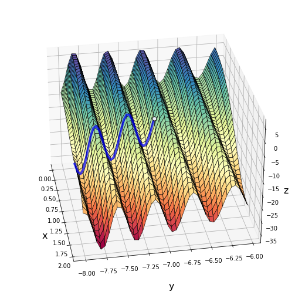

```python
#ploha
xkor = arange(0, 2, 0.05)
ykor = arange(-8, -6, 0.05)
X, Y = meshgrid(xkor,ykor)
Z = X**2*Y+Y*sin(X**2+Y**2)
#plava krivulja
tk = linspace(0, 0.25, 30)
xk = 1+tk
yk = -7-4*tk
zk = xk**2*yk+yk*sin(xk**2+yk**2)
#slika
figsize(12,9)
ax = axes(projection='3d')
ax.plot_surface(X, Y, Z, cmap=cm.Spectral, linewidth=0.6,alpha=1,edgecolors='k')
ax.plot(xk, yk, zk, c='b',lw=4,alpha=0.7,zorder=3)
ax.plot([1], [-7], [F.evalf(subs={x:1,y:-7})], markerfacecolor='w', markeredgecolor='k',
        marker='o', markersize=7, alpha=0.9,zorder=10)
ax.set_xlabel('\nx', linespacing=3.2,fontsize=16)
ax.set_ylabel('\ny', linespacing=3.2,fontsize=16)
ax.set_zlabel('z', linespacing=3.2,fontsize=16)
ax.view_init(elev=30,azim=-10)
ax.dist = 10
```

### 2. zadatak

Odredite lokalne ekstreme funkcije $f(x,y)=\big(x^2-2y^2\big)\cdot2.415^{x-y}.$

### Rješenje

Kako je *sympy* modul prvenstveno namijenjen za simbolički račun, broj $2.415$ je najbolje reprezentirani kao egzaktni racionalni broj. To je prvenstveno bitno kod rješavanja sustava jednadžbi da izbjegnemo probleme s numerikom.

```python
f=(x**2-2*y**2)*sp.Rational(2415,1000)**(x-y)
f
```

$\displaystyle \left(\frac{483}{200}\right)^{x - y} \left(x^{2} - 2 y^{2}\right)$

#### Parcijalne derivacije

```python
fx=f.diff(x)
fx
```

$\displaystyle 2 \left(\frac{483}{200}\right)^{x - y} x + \left(\frac{483}{200}\right)^{x - y} \left(x^{2} - 2 y^{2}\right) \log{\left(\frac{483}{200} \right)}$

```python
fy=f.diff(y)
fy
```

$\displaystyle - 4 \left(\frac{483}{200}\right)^{x - y} y - \left(\frac{483}{200}\right)^{x - y} \left(x^{2} - 2 y^{2}\right) \log{\left(\frac{483}{200} \right)}$

#### Stacionarne točke

```python
stac=sp.solve([fx,fy],[x,y])
stac
```

$\displaystyle \left[ \left( 0, \ 0\right), \ \left( \frac{- \sqrt{\left(1 - \log{\left(483^{\log{\left(200^{\frac{16}{\log{\left(\frac{200}{483} \right)}^{2}}} \right)}} \right)}\right) \log{\left(\frac{200}{483} \right)}^{2} + 8 \log{\left(200 \right)}^{2} + 8 \log{\left(483 \right)}^{2}} + \log{\left(\frac{200}{483} \right)}}{\log{\left(\frac{200}{483} \right)}^{2}}, \ \frac{2}{\log{\left(\frac{200}{483} \right)}}\right)\right]$

```python
stac1=stac[0]
stac2=stac[1]
```

```python
stac1
```

$\displaystyle \left( 0, \ 0\right)$

Pretvorimo simboličke izraze kod druge stacionarne točke u realne brojeve.

```python
stac2=tuple(map(lambda x: sp.N(x), stac2))
stac2
```

$\displaystyle \left( -4.53669415241996, \ -2.26834707620998\right)$

#### Hesseova matrica

```python
hess_f=sp.hessian(f,[x,y])
hess_f
```

$\displaystyle \left[\begin{matrix}4 \left(\frac{483}{200}\right)^{x - y} x \log{\left(\frac{483}{200} \right)} + \left(\frac{483}{200}\right)^{x - y} \left(x^{2} - 2 y^{2}\right) \log{\left(\frac{483}{200} \right)}^{2} + 2 \left(\frac{483}{200}\right)^{x - y} & - 2 \left(\frac{483}{200}\right)^{x - y} x \log{\left(\frac{483}{200} \right)} - 4 \left(\frac{483}{200}\right)^{x - y} y \log{\left(\frac{483}{200} \right)} - \left(\frac{483}{200}\right)^{x - y} \left(x^{2} - 2 y^{2}\right) \log{\left(\frac{483}{200} \right)}^{2}\\- 2 \left(\frac{483}{200}\right)^{x - y} x \log{\left(\frac{483}{200} \right)} - 4 \left(\frac{483}{200}\right)^{x - y} y \log{\left(\frac{483}{200} \right)} - \left(\frac{483}{200}\right)^{x - y} \left(x^{2} - 2 y^{2}\right) \log{\left(\frac{483}{200} \right)}^{2} & 8 \left(\frac{483}{200}\right)^{x - y} y \log{\left(\frac{483}{200} \right)} + \left(\frac{483}{200}\right)^{x - y} \left(x^{2} - 2 y^{2}\right) \log{\left(\frac{483}{200} \right)}^{2} - 4 \left(\frac{483}{200}\right)^{x - y}\end{matrix}\right]$

Točka $(0,0)$ je sedlasta točka funkcije $f$.

```python
H1=hess_f.evalf(subs={x:stac1[0],y:stac1[1]})
H1
```

$\displaystyle \left[\begin{matrix}2.0 & 0\\0 & -4.0\end{matrix}\right]$

```python
H1.det()
```

$\displaystyle -8.0$

U točki $(-4.53669415241996, -2.26834707620998)$ funkcija $f$ ima lokalni maksimum koji iznosi $1.39270791539802.$

```python
H2=hess_f.evalf(subs={x:stac2[0],y:stac2[1]})
H2
```

$\displaystyle \left[\begin{matrix}-0.812011699419676 & 1.0826822658929\\1.0826822658929 & -1.62402339883935\end{matrix}\right]$

```python
H2.det()
```

$\displaystyle 0.146525111109874$

```python
f.evalf(subs={x:stac2[0],y:stac2[1]})
```

$\displaystyle 1.39270791539802$

#### Graf funkcije $f$

Na slici ne vidimo baš rezultate koje smo dobili računski.

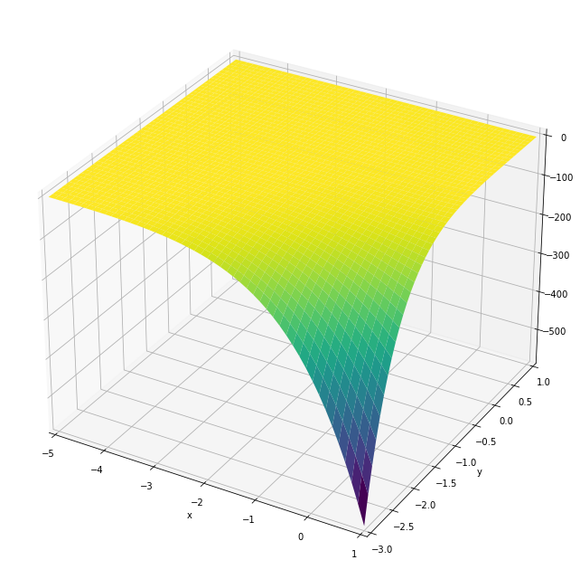

```python
sp.plotting.plot3d(f,(x,-5,1),(y,-3,1),xlabel='x',ylabel='y');
```

#### matplotlib slika

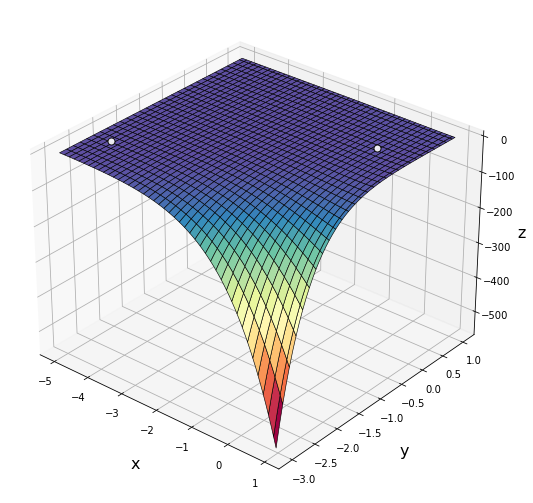

```python
#ploha
xkor = arange(-5, 1, 0.07)
ykor = arange(-3, 1, 0.07)
X, Y = meshgrid(xkor,ykor)
Z = (X**2-2*Y**2)*2.415**(X-Y)
#slika
figsize(12,9)
ax = axes(projection='3d')
ax.plot_surface(X, Y, Z, cmap=cm.Spectral, linewidth=0.6,alpha=1,edgecolors='k')
ax.plot([0,stac2[0]], [0,stac2[1]], [f.evalf(subs={x:0,y:0}),f.evalf(subs={x:stac2[0],y:stac2[1]})],
        markerfacecolor='w', markeredgecolor='k', marker='o', ls='', markersize=7, alpha=0.9,zorder=10)
ax.set_xlabel('\nx', linespacing=3.2,fontsize=16)
ax.set_ylabel('\ny', linespacing=3.2,fontsize=16)
ax.set_zlabel('z', linespacing=3.2,fontsize=16)
ax.view_init(elev=30,azim=-50)
ax.dist = 10
```

Ako plohu dovoljno zumiramo oko točke $(0,0)$, možemo na slici uočiti da se radi o sedlastoj točki.

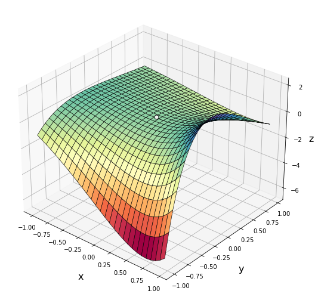

```python
#ploha
xkor = arange(-1, 1, 0.07)
ykor = arange(-1, 1, 0.07)
X, Y = meshgrid(xkor,ykor)
Z = (X**2-2*Y**2)*2.415**(X-Y)
#slika
figsize(12,9)
ax = axes(projection='3d')
ax.plot_surface(X, Y, Z, cmap=cm.Spectral, linewidth=0.6,alpha=1,edgecolors='k')
ax.plot([0], [0], [f.evalf(subs={x:0,y:0})], markerfacecolor='w', markeredgecolor='k',
        marker='o', markersize=7, alpha=0.9,zorder=10)
ax.set_xlabel('\nx', linespacing=3.2,fontsize=16)
ax.set_ylabel('\ny', linespacing=3.2,fontsize=16)
ax.set_zlabel('z', linespacing=3.2,fontsize=16)
ax.view_init(elev=30,azim=-50)
ax.dist = 10
```

Ako plohu dovoljno zumiramo oko točke $(-4.53669415241996,-2.26834707620998)$, možemo na slici uočiti da se radi o točki lokalnog maksimuma.

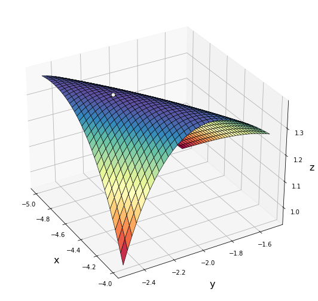

```python
#ploha
xkor = arange(-5, -4, 0.03)
ykor = arange(-2.5, -1.5, 0.03)
X, Y = meshgrid(xkor,ykor)
Z = (X**2-2*Y**2)*2.415**(X-Y)
#slika
figsize(12,9)
ax = axes(projection='3d')
ax.plot_surface(X, Y, Z, cmap=cm.Spectral, linewidth=0.6,alpha=1,edgecolors='k')
ax.plot([stac2[0]], [stac2[1]], [f.evalf(subs={x:stac2[0],y:stac2[1]})],
        markerfacecolor='w', markeredgecolor='k', marker='o', markersize=7, alpha=0.9,zorder=10)
ax.set_xlabel('\nx', linespacing=3.2,fontsize=16)
ax.set_ylabel('\ny', linespacing=3.2,fontsize=16)
ax.set_zlabel('z', linespacing=3.2,fontsize=16)
ax.view_init(elev=30,azim=-30)
ax.dist = 10
```

### 3. zadatak

Odredite ekstreme funkcije $G(x,y,z)=(x-2)^2+(y-3)^2+(z+1.34)^2$ uz uvjet $\dfrac{x^2}{2}+\dfrac{y^2}{3}+\dfrac{z^2}{5.21}=1.$

### Rješenje

```python
G=(x-2)**2+(y-3)**2+(z+sp.Rational(134,100))**2
G
```

$\displaystyle \left(x - 2\right)^{2} + \left(y - 3\right)^{2} + \left(z + \frac{67}{50}\right)^{2}$

#### Lagrangeova funkcija

```python
L=G + t*(sp.Rational(1,2)*x**2+sp.Rational(1,3)*y**2+sp.Rational(100,521)*z**2-1)
L
```

$\displaystyle t \left(\frac{x^{2}}{2} + \frac{y^{2}}{3} + \frac{100 z^{2}}{521} - 1\right) + \left(x - 2\right)^{2} + \left(y - 3\right)^{2} + \left(z + \frac{67}{50}\right)^{2}$

#### Parcijalne derivacije

```python
Lx=L.diff(x)
Lx
```

$\displaystyle t x + 2 x - 4$

```python
Ly=L.diff(y)
Ly
```

$\displaystyle \frac{2 t y}{3} + 2 y - 6$

```python
Lz=L.diff(z)
Lz
```

$\displaystyle \frac{200 t z}{521} + 2 z + \frac{67}{25}$

```python
Lt=L.diff(t)
Lt
```

$\displaystyle \frac{x^{2}}{2} + \frac{y^{2}}{3} + \frac{100 z^{2}}{521} - 1$

#### Stacionarne točke

Nije moguće egzaktno riješiti zadani sustav jednadžbi pa trebamo ići na numeričko rješavanje da pronađemo približno rješenje.

```python
sp.solve([Lx,Ly,Lz,Lt],[x,y,z,t])
```

$\displaystyle \left[ \right]$

Vidimo da iz prve tri jednadžbe možemo lagano nepoznanice $x,y,z$ izraziti pomoću nepoznanice $t$.

```python
xt=sp.solve_linear(Lx,symbols=[x])
xt
```

$\displaystyle \left( x, \ \frac{4}{t + 2}\right)$

```python
yt=sp.solve_linear(Ly,symbols=[y])
yt
```

$\displaystyle \left( y, \ \frac{18}{2 t + 6}\right)$

```python
zt=sp.solve_linear(Lz,symbols=[z])
zt
```

$\displaystyle \left( z, \ - \frac{34907}{5000 t + 26050}\right)$

Uvrstimo dobivene izraze u zadnju jednadžbu, tj. uvjet.

```python
jed=Lt.subs({x:xt[1],y:yt[1],z:zt[1]})
jed
```

$\displaystyle -1 + \frac{233876900}{\left(5000 t + 26050\right)^{2}} + \frac{108}{\left(2 t + 6\right)^{2}} + \frac{8}{\left(t + 2\right)^{2}}$

Malo sredimo jednadžbu tako da ju svedemo na traženje nultočaka polinoma.

```python
jed.factor()
```

$\displaystyle - \frac{250000 t^{6} + 5105000 t^{5} + 30997256 t^{4} + 25682560 t^{3} - 359042403 t^{2} - 1166904540 t - 1061383284}{25 \left(t + 2\right)^{2} \left(t + 3\right)^{2} \left(100 t + 521\right)^{2}}$

```python
jed.factor().as_numer_denom()
```

$\displaystyle \left( - 250000 t^{6} - 5105000 t^{5} - 30997256 t^{4} - 25682560 t^{3} + 359042403 t^{2} + 1166904540 t + 1061383284, \ 25 \left(t + 2\right)^{2} \left(t + 3\right)^{2} \left(100 t + 521\right)^{2}\right)$

Uzmemo samo brojnik.

```python
jed=jed.factor().as_numer_denom()[0]
jed
```

$\displaystyle - 250000 t^{6} - 5105000 t^{5} - 30997256 t^{4} - 25682560 t^{3} + 359042403 t^{2} + 1166904540 t + 1061383284$

Pretvorimo brojnik u klasu polinom i numerički pronađemo sve njegove nultočke.

```python
jed=jed.as_poly()
jed
```

$\displaystyle \operatorname{Poly}{\left( -250000 t^{6} - 5105000 t^{5} - 30997256 t^{4} - 25682560 t^{3} + 359042403 t^{2} + 1166904540 t + 1061383284, t, domain=\mathbb{Z} \right)}$

```python
nultocke=jed.nroots()
nultocke
```

$\displaystyle \left[ -10.2484203805903, \ 3.58525133701441, \ -4.65049147736999 - 0.926606616726492 i, \ -4.65049147736999 + 0.926606616726492 i, \ -2.22792400084209 - 0.418347028062213 i, \ -2.22792400084209 + 0.418347028062213 i\right]$

Zanimaju nas samo realna rješenja.

```python
rj=list(filter(lambda x: sp.im(x)==0, nultocke))
rj
```

$\displaystyle \left[ -10.2484203805903, \ 3.58525133701441\right]$

```python
t1,t2=rj
```

```python
t1
```

$\displaystyle -10.2484203805903$

```python
t2
```

$\displaystyle 3.58525133701441$

Izračunamo pripadne vrijednosti nepoznanica $x,y,z.$

```python
x1=xt[1].evalf(subs={t:t1})
x1
```

$\displaystyle -0.484941336090555$

```python
x2=xt[1].evalf(subs={t:t2})
x2
```

$\displaystyle 0.716171888898055$

```python
y1=yt[1].evalf(subs={t:t1})
y1
```

$\displaystyle -1.24164983919808$

```python
y2=yt[1].evalf(subs={t:t2})
y2
```

$\displaystyle 1.36669043281807$

```python
z1=zt[1].evalf(subs={t:t1})
z1
```

$\displaystyle 1.38563269291597$

```python
z2=zt[1].evalf(subs={t:t2})
z2
```

$\displaystyle -0.793769243480183$

Kako je uvjet $\frac{x^2}{2}+\frac{y^2}{3}+\frac{z^2}{5.21}=1$ kompaktni skup u $\mathbb{R}^3$, funkcija $G$ u dobivenim dvjema stacionarnim točkama postiže globalne uvjetne ekstreme. Uvjet geometrijski predstavlja elipsoid u prostoru.

U točki $(-0.484941336090555,-1.24164983919808,1.38563269291597)$ funkcija $G$ postiže uvjetni globalni maksimum koji iznosi $31.595600378873.$

```python
G.evalf(subs={x:x1,y:y1,z:z1})
```

$\displaystyle 31.595600378873$

U točki $(0.716171888898055,1.36669043281807,-0.793769243480183)$ funkcija $G$ postiže uvjetni globalni minimum koji iznosi $4.61428280047182.$

```python
G.evalf(subs={x:x2,y:y2,z:z2})
```

$\displaystyle 4.61428280047182$

Mogli smo sustav riješiti numerički direktno pomoću naredbe *nsolve*. Međutim, tada moramo navesti neku početnu aproksimaciju od pravog rješenja. Ukoliko je ta aproksimacija loša, možda nećemo uspjeti pronaći rješenje ili će dobiveno rješenje biti manje precizno. Pogledajte dolje nekoliko primjera izvođenja te naredbe s obzirom na različite početne aproksimacije. Prednost ovog načina je manje pisanja koda, a nedostatak je da moramo unaprijed znati koliko ima rješenja ukoliko ih želimo sva pronaći. Prednost ranijeg postupka jest da ne moramo unaprijed znati koliko imamo rješenja, nego korak po korak dolazimo do polinomijalne jednadžbe s jednom nepoznanicom čija rješenja možemo pronaći bez početnih aproksimacija. Nedostatak je da moramo pisati više koda, ali sigurno dolazimo do svih rješenja.

```python
sp.nsolve([Lx,Ly,Lz,Lt],[x,y,z,t],[-3,5,1,-9])
```

$\displaystyle \left[\begin{matrix}-0.484941336090555\\-1.24164983919808\\1.38563269291597\\-10.2484203805903\end{matrix}\right]$

```python
sp.nsolve([Lx,Ly,Lz,Lt],[x,y,z,t],[1,2,-1,4])
```

$\displaystyle \left[\begin{matrix}0.716171888898055\\1.36669043281807\\-0.793769243480183\\3.58525133701441\end{matrix}\right]$

```python
sp.nsolve([Lx,Ly,Lz,Lt],[x,y,z,t],[20,13,30,100])
```

$\displaystyle \left[\begin{matrix}0.716171888898055\\1.36669043281807\\-0.793769243480183\\3.58525133701441\end{matrix}\right]$

```python
sp.nsolve([Lx,Ly,Lz,Lt],[x,y,z,t],[200,103,300,100])
```

```
---------------------------------------------------------------------------
ValueError                                Traceback (most recent call last)
/tmp/ipykernel_25479/3771905655.py in <module>
----> 1 sp.nsolve([Lx,Ly,Lz,Lt],[x,y,z,t],[200,103,300,100])

/usr/lib/python3.9/site-packages/sympy/utilities/decorator.py in func_wrapper(*args, **kwargs)
     86         dps = mpmath.mp.dps
     87         try:
---> 88             return func(*args, **kwargs)
     89         finally:
     90             mpmath.mp.dps = dps

/usr/lib/python3.9/site-packages/sympy/solvers/solvers.py in nsolve(dict, *args, **kwargs)
   2952     J = lambdify(fargs, J, modules)
   2953     # solve the system numerically
-> 2954     x = findroot(f, x0, J=J, **kwargs)
   2955     if as_dict:
   2956         return [dict(zip(fargs, [sympify(xi) for xi in x]))]

/usr/lib/python3.9/site-packages/mpmath/calculus/optimization.py in findroot(ctx, f, x0, solver, tol, verbose, verify, **kwargs)
    983             xl = x
    984         if verify and norm(f(*xl))**2 > tol: # TODO: better condition?
--> 985             raise ValueError('Could not find root within given tolerance. '
    986                              '(%s > %s)\n'
    987                              'Try another starting point or tweak arguments.'

ValueError: Could not find root within given tolerance. (0.000438386331676975702112 > 2.16840434497100886801e-19)
Try another starting point or tweak arguments.
```

```python
sp.nsolve([Lx,Ly,Lz,Lt],[x,y,z,t],[200,103,300,100],verify=False)
```

$\displaystyle \left[\begin{matrix}0.71707374916245\\1.36710242518659\\-0.794306945435048\\3.5602937415546\end{matrix}\right]$

#### Geometrijska interpretacija

Funkcija $G$ zapravo daje kvadrat udaljenosti točke $(2,3,-1.34)$ od točke $(x,y,z)$. U zadatku se zapravo traže na elipsoidu $\frac{x^2}{2}+\frac{y^2}{3}+\frac{z^2}{5.21}=1$ najbliža i najudaljenija točka od točke $(2,3,-1.34).$

Točka $(-0.484941336090555,-1.24164983919808,1.38563269291597)$ je najudaljenija točka na zadanom elipsoidu od točke $(2,3,-1.34)$ i njihova udaljenost iznosi $5.62099638666251.$

```python
d1=G.evalf(subs={x:x1,y:y1,z:z1})
sp.sqrt(d1)
```

$\displaystyle 5.62099638666251$

Točka $(0.716171888898055,1.36669043281807,-0.793769243480183)$ je najbliža točka na zadanom elipsoidu od točke $(2,3,-1.34)$ i njihova udaljenost iznosi $2.14808817334667.$

```python
d2=G.evalf(subs={x:x2,y:y2,z:z2})
sp.sqrt(d2)
```

$\displaystyle 2.14808817334667$

##### 3D slika

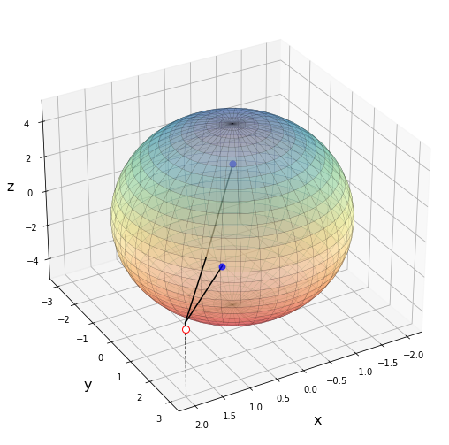

```python
#ploha
uk = linspace(0, 2*pi, 80)
vk = linspace(0, pi, 60)
xk, yk = meshgrid(uk,vk)
X = 2*cos(xk)*sin(yk)
Y = 3*sin(uk)*sin(yk)
Z = 5.21*cos(yk)
#slika
figsize(12,9)
ax = axes(projection='3d')
ax.plot_surface(X, Y, Z, cmap=cm.Spectral, linewidth=0.3,alpha=0.5,edgecolors=(0,0,0,0.3))
ax.plot([0.97,2], [1.25,3], [-0.21,-1], marker='', alpha=1, c='k',zorder=3)
ax.plot([2,2], [3,3], [-1,-5.2], marker='', alpha=1, c='k',ls='--',lw=1,zorder=3)
ax.plot([0.97,x1], [1.25,y1], [-0.21,z1], marker='', alpha=1, c='k')
ax.plot([2,x2], [3,y2], [-1,z2], marker='', alpha=1, c='k',zorder=3)
ax.plot([x1], [y1], [z1], markerfacecolor='b', markeredgecolor='b',
         marker='o', markersize=7, alpha=1)
ax.plot([2], [3], [-1.34], markerfacecolor='w', markeredgecolor='r',
         marker='o', markersize=8, alpha=1,zorder=10)
ax.plot([x2], [y2], [z2], markerfacecolor='b', markeredgecolor='b',
         marker='o', markersize=7, alpha=0.7, zorder=10)
ax.set_xlabel('\nx', linespacing=3.2,fontsize=16)
ax.set_ylabel('\ny', linespacing=3.2,fontsize=16)
ax.set_zlabel('z', linespacing=3.2,fontsize=16)
ax.set_zlim3d(-5,5)
ax.view_init(elev=30,azim=60)
ax.dist = 10
```

### 4. zadatak

Odredite ekstreme funkcije $f(x,y)=2x+3y$ uz uvjet $xy=2.$

### Rješenje

```python
f=2*x+3*y
f
```

$\displaystyle 2 x + 3 y$

#### Lagrangeova funkcija

```python
L=f+t*(x*y-2)
L
```

$\displaystyle t \left(x y - 2\right) + 2 x + 3 y$

#### Parcijalne derivacije

```python
Lx=L.diff(x)
Lx
```

$\displaystyle t y + 2$

```python
Ly=L.diff(y)
Ly
```

$\displaystyle t x + 3$

```python
Lt=L.diff(t)
Lt
```

$\displaystyle x y - 2$

#### Stacionarne točke

```python
stac=sp.solve([Lx,Ly,Lt],[x,y,t])
stac
```

$\displaystyle \left[ \left( - \sqrt{3}, \ - \frac{2 \sqrt{3}}{3}, \ \sqrt{3}\right), \ \left( \sqrt{3}, \ \frac{2 \sqrt{3}}{3}, \ - \sqrt{3}\right)\right]$

#### Hesseova matrica

```python
hess_L=sp.hessian(L,[t,x,y])
hess_L
```

$\displaystyle \left[\begin{matrix}0 & y & x\\y & 0 & t\\x & t & 0\end{matrix}\right]$

U točki $\Big(\!-\!\sqrt{3},-\frac{2}{3}\sqrt{3}\Big)$ funkcija $f$ postiže uvjetni lokalni maksimum koji iznosi $-4\sqrt{3}.$

```python
hess_L.evalf(subs={x:stac[0][0],y:stac[0][1],t:stac[0][2]})
```

$\displaystyle \left[\begin{matrix}0 & -1.15470053837925 & -1.73205080756888\\-1.15470053837925 & 0 & 1.73205080756888\\-1.73205080756888 & 1.73205080756888 & 0\end{matrix}\right]$

```python
H1=hess_L.subs({x:stac[0][0],y:stac[0][1],t:stac[0][2]})
H1
```

$\displaystyle \left[\begin{matrix}0 & - \frac{2 \sqrt{3}}{3} & - \sqrt{3}\\- \frac{2 \sqrt{3}}{3} & 0 & \sqrt{3}\\- \sqrt{3} & \sqrt{3} & 0\end{matrix}\right]$

```python
H1.det()
```

$\displaystyle 4 \sqrt{3}$

```python
f.subs({x:stac[0][0],y:stac[0][1]})
```

$\displaystyle - 4 \sqrt{3}$

```python
f1=f.evalf(subs={x:stac[0][0],y:stac[0][1]})
f1
```

$\displaystyle -6.92820323027551$

U točki $\Big(\sqrt{3},\frac{2}{3}\sqrt{3}\Big)$ funkcija $f$ postiže uvjetni lokalni minimum koji iznosi $4\sqrt{3}.$

```python
hess_L.evalf(subs={x:stac[1][0],y:stac[1][1],t:stac[1][2]})
```

$\displaystyle \left[\begin{matrix}0 & 1.15470053837925 & 1.73205080756888\\1.15470053837925 & 0 & -1.73205080756888\\1.73205080756888 & -1.73205080756888 & 0\end{matrix}\right]$

```python
H2=hess_L.subs({x:stac[1][0],y:stac[1][1],t:stac[1][2]})
H2
```

$\displaystyle \left[\begin{matrix}0 & \frac{2 \sqrt{3}}{3} & \sqrt{3}\\\frac{2 \sqrt{3}}{3} & 0 & - \sqrt{3}\\\sqrt{3} & - \sqrt{3} & 0\end{matrix}\right]$

```python
H2.det()
```

$\displaystyle - 4 \sqrt{3}$

```python
f.subs({x:stac[1][0],y:stac[1][1]})
```

$\displaystyle 4 \sqrt{3}$

```python
f2=f.evalf(subs={x:stac[1][0],y:stac[1][1]})
f2
```

$\displaystyle 6.92820323027551$

#### 3D slika

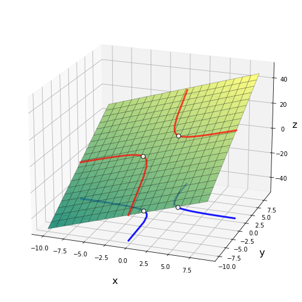

```python
#ploha
xkor = arange(-10, 10, 1)
ykor = arange(-10,10,1)
X, Y = meshgrid(xkor,ykor)
Z = 2*X+3*Y
#crvena i plava krivulja
tk1 = linspace(0.23, 9, 40)
yk1 = 2 / tk1
zk1 = 2*tk1 + 3*yk1
tk2 = linspace(-10,-0.2, 40)
yk2 = 2 / tk2
zk2 = 2*tk2 + 3*yk2
#slika
figsize(12,9)
ax = axes(projection='3d')
ax.plot_surface(X, Y, Z, cmap=cm.summer, linewidth=0.6,alpha=0.8,edgecolors=(0,0,0,0.4))
ax.plot(tk1, yk1, zk1, c='r',lw=3,alpha=0.7,zorder=3)
ax.plot(tk2, yk2, zk2, c='r',lw=3,alpha=0.7,zorder=3)
ax.plot(tk1, yk1, -50, c='b',lw=3,alpha=0.9)
ax.plot(tk2, yk2, -50, c='b',lw=3,alpha=0.9)
ax.plot([stac[0][0],stac[1][0],stac[0][0],stac[1][0]], [stac[0][1],stac[1][1],stac[0][1],stac[1][1]], [f1,f2,-50,-50],
         markerfacecolor='w', markeredgecolor='k', ls='', marker='o', markersize=7, alpha=0.9,zorder=10)
ax.set_xlabel('\nx', linespacing=3.2,fontsize=16)
ax.set_ylabel('\ny', linespacing=3.2,fontsize=16)
ax.set_zlabel('z', linespacing=3.2,fontsize=16)
ax.set_zlim3d(-50,50)
ax.view_init(elev=20,azim=-70)
ax.dist = 10
```

### 5. zadatak

Zadana je ploha $r(u,v)=\big(\sin{u},\,\sin{v},\,\sin{(u+v)}\big)$ i točka $A$ na toj plohi s parametrima $u=1.25$, $v=1.35$. Odredite jednadžbu tangencijalne ravnine na zadanu plohu u točki $A$.

### Rješenje

```python
r=sp.Matrix([sp.sin(u),sp.sin(v),sp.sin(u+v)])
r
```

$\displaystyle \left[\begin{matrix}\sin{\left(u \right)}\\\sin{\left(v \right)}\\\sin{\left(u + v \right)}\end{matrix}\right]$

#### Parcijalne derivacije

```python
ru=r.diff(u)
ru
```

$\displaystyle \left[\begin{matrix}\cos{\left(u \right)}\\0\\\cos{\left(u + v \right)}\end{matrix}\right]$

```python
rv=r.diff(v)
rv
```

$\displaystyle \left[\begin{matrix}0\\\cos{\left(v \right)}\\\cos{\left(u + v \right)}\end{matrix}\right]$

Vektori koji određuju tangencijalnu ravninu u točki plohe s parametrima $u=1.25,$ $v=1.35$

```python
v1=ru.subs({u:1.25,v:1.35})
v1
```

$\displaystyle \left[\begin{matrix}0.315322362395269\\0\\-0.856888753368947\end{matrix}\right]$

```python
v2=rv.subs({u:1.25,v:1.35})
v2
```

$\displaystyle \left[\begin{matrix}0\\0.219006687093041\\-0.856888753368947\end{matrix}\right]$

#### Normala tangencijalne ravnine

```python
ruxrv=ru.cross(rv)
ruxrv
```

$\displaystyle \left[\begin{matrix}- \cos{\left(v \right)} \cos{\left(u + v \right)}\\- \cos{\left(u \right)} \cos{\left(u + v \right)}\\\cos{\left(u \right)} \cos{\left(v \right)}\end{matrix}\right]$

Normala tangencijalne ravnine u točki plohe s parametrima $u=1.25,$ $v=1.35$

```python
nor=ruxrv.subs({u:1.25,v:1.35})
nor
```

$\displaystyle \left[\begin{matrix}0.187664367082619\\0.270196186022233\\0.0690577059545392\end{matrix}\right]$

#### Kartezijeve koordinate točke $A$

```python
A=r.subs({u:1.25,v:1.35})
A
```

$\displaystyle \left[\begin{matrix}0.948984619355586\\0.975723357826659\\0.515501371821464\end{matrix}\right]$

#### Jednadžba tangencijalne ravnine zadane plohe u točki $A$

```python
rav=sp.Plane(sp.Point3D(A),nor)
rav.equation()
```

$\displaystyle \frac{187664367082619 x}{1000000000000000} + \frac{270196186022233 y}{1000000000000000} + \frac{43161066221587 z}{625000000000000} - \frac{2386633350072420819226090293349}{5000000000000000000000000000000}$

```python
rav.equation().evalf()
```

$\displaystyle 0.187664367082619 x + 0.270196186022233 y + 0.0690577059545392 z - 0.477326670014484$

#### 3D slika

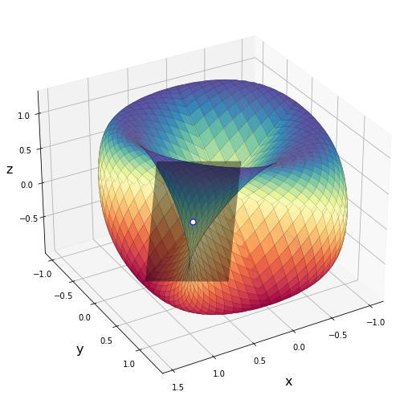

```python
#ploha
uk = linspace(0, 2*pi, 100)
vk = linspace(0, 2*pi, 100)
xk, yk = meshgrid(uk,vk)
X = sin(xk)
Y = sin(yk)
Z = sin(xk+yk)
#tangencijalna ravnina
alpha=0.8
u1 = linspace(-0.6,0.6,2)
u2 = linspace(-1.6,1.6,2)
xr,yr = meshgrid(u1,u2)
xrav = float(A[0])+float(v1[0])*(xr*cos(alpha)-sin(alpha)*yr)+float(v2[0])*(yr*cos(alpha)+sin(alpha)*xr)
yrav = float(A[1])+float(v1[1])*(xr*cos(alpha)-sin(alpha)*yr)+float(v2[1])*(yr*cos(alpha)+sin(alpha)*xr)
zrav = float(A[2])+float(v1[2])*(xr*cos(alpha)-sin(alpha)*yr)+float(v2[2])*(yr*cos(alpha)+sin(alpha)*xr)
#slika
figsize(12,9)
ax = axes(projection='3d')
ax.plot_surface(X, Y, Z, cmap=cm.Spectral, linewidth=0.3,alpha=0.9,edgecolors=(0,0,0,0.3))
ax.plot_surface(xrav, yrav, zrav, cmap=cm.gray, linewidth=0.1,alpha=0.4,edgecolors=(0,0,0,0.2))
ax.plot([A[0]], [A[1]], [A[2]], markerfacecolor='w', markeredgecolor='b',
         marker='o', markersize=7, alpha=1,zorder=10)
ax.set_xlabel('\nx', linespacing=3.2,fontsize=16)
ax.set_ylabel('\ny', linespacing=3.2,fontsize=16)
ax.set_zlabel('z', linespacing=3.2,fontsize=16)
ax.view_init(elev=30,azim=60)
ax.dist = 10
```